# New analysis method - Human Brain Research

Nitay Alon

February 27, 2019

In this paper we use a new analysis method to examine the Human Brain structure as a function of sex. The analysis method is described in section 1, the over all results are presented in section 2 followed by selected examples in section 3 and a summary.

# Section 1 - New analysis method

Previous research indicated a problem on non normality (highly skewed, kurtosis data). In addition the overall brain volume has an effect on the distribution of each feature and it is necessary to adjust the feature size for the brain volume. The new analysis method is based on three steps, for each feature:

1. Apply linear regression on the feature size as a function of the over all brain volume:
   $$y = cVolume^\alpha \implies log(y) = log(c) + \alpha log(Volume)$$
2. Replace each residual with the proper *z-score* 2.1. Winsorized observations with absolute value over 3
3. Apply un constrained EM over the main hypothesis of our work

# Section 2 - Over all results

## Single distribution vs Mixture model

First we analyze the simple single distribution vs mixture model hypothesis:

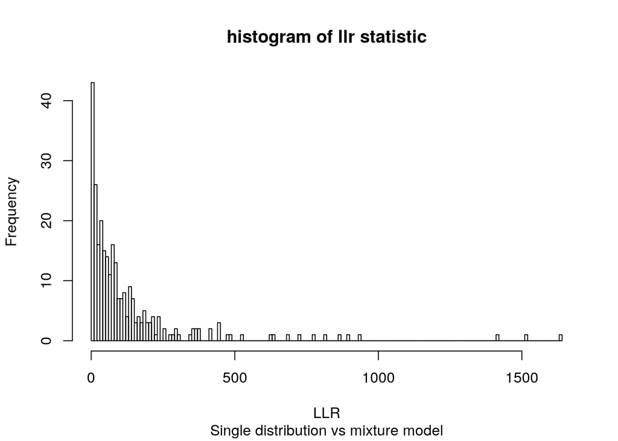

```r
simple_vs_mixture_model_llrt <- sapply(results.list, function(x){x$hypothesis_results$simple_vs_compostie_llrt})
hist(simple_vs_mixture_model_llrt, breaks = 150, main = "histogram of llr statistic", sub = "Single distribution vs mixture model",xlab = "LLR")
```

It is visible that for some features the null hypothesis isn’t rejected:

```r
rejection_region <- qchisq(0.99,4)
(simple_vs_mixture_model_llrt > rejection_region) %>%
  table() %>%
  prop.table()
```

```
## .
##     FALSE      TRUE
## 0.1821429 0.8178571
```

Taking in random some non significant features:

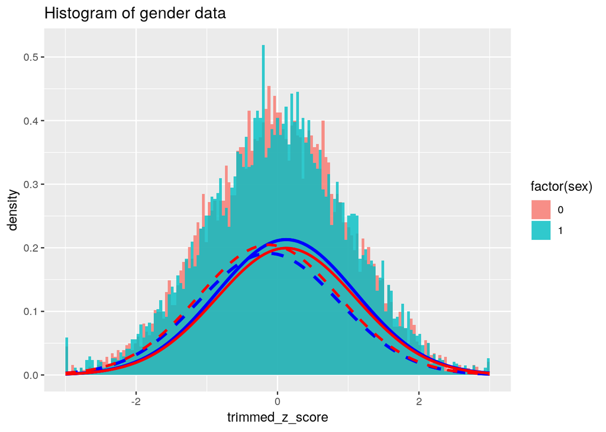

```r
list_of_single_distribution_features <- list.of.names[simple_vs_mixture_model_llrt < rejection_region]

analyzeFullBrainFeature(results.list[names(results.list) == list_of_single_distribution_features[1]],plot = T)
```

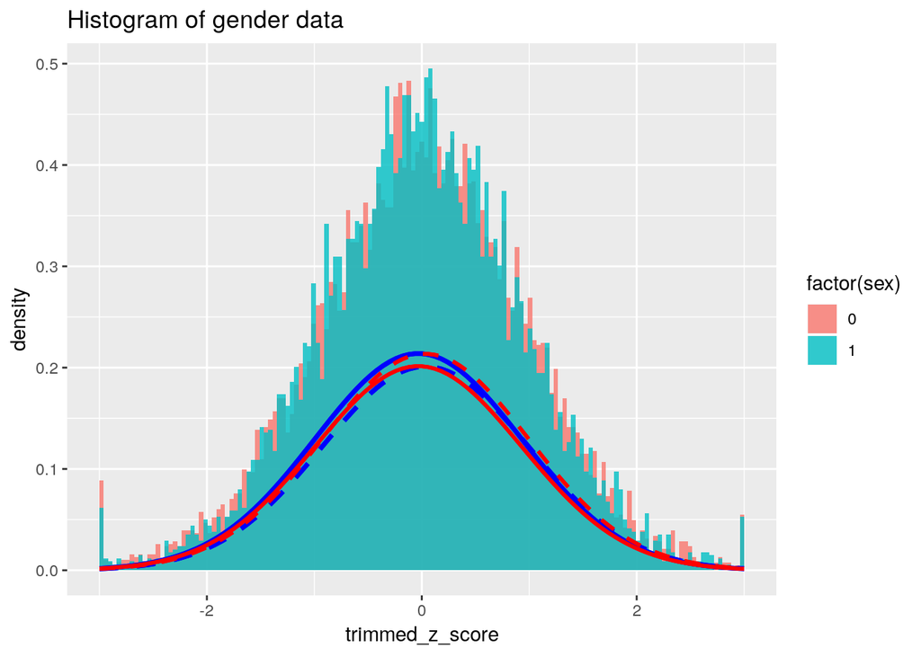

```r
analyzeFullBrainFeature(results.list[names(results.list) == list_of_single_distribution_features[10]],plot = T)
```

In contrary, if we take for example a high llr feature:

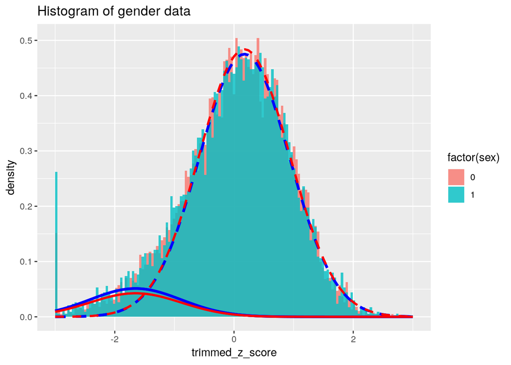

```r
list_of_composite_distribution_features <- list.of.names[simple_vs_mixture_model_llrt > rejection_region]

analyzeFullBrainFeature(results.list[names(results.list) == list_of_composite_distribution_features[2]],plot = T)
```

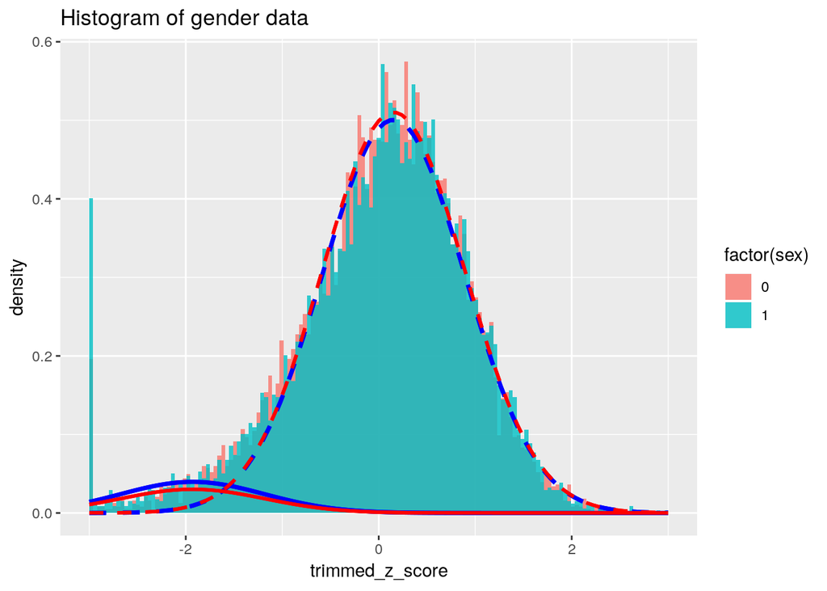

```r
analyzeFullBrainFeature(results.list[names(results.list) == list_of_composite_distribution_features[10]],plot = T)
```

## Pure types vs Mixture model

Next we test the hypothesis of pure types vs mixture model:

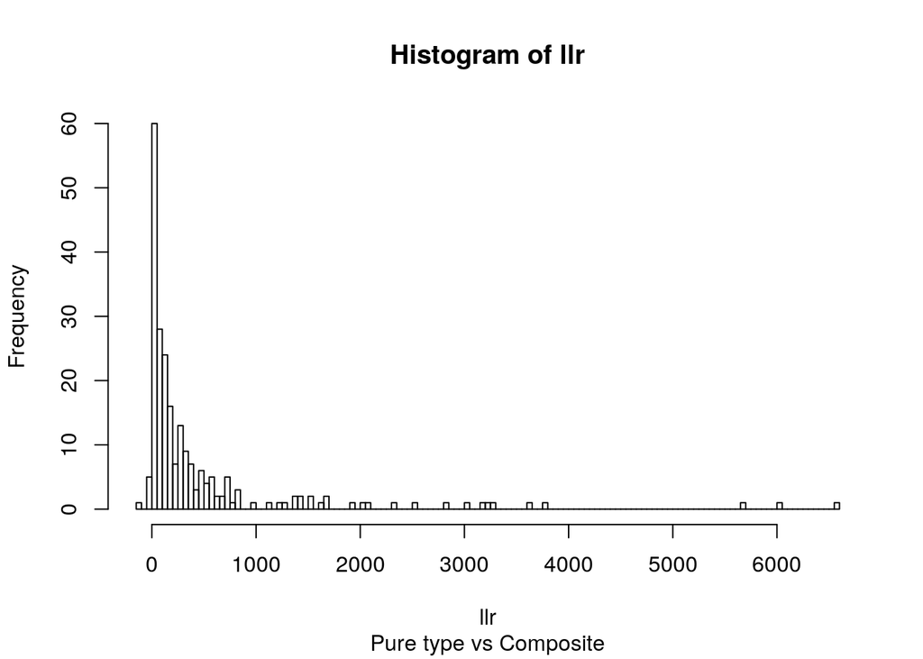

```r
hist(pure_vs_mixture_model_llrt, breaks = 100, main = "Histogram of llr",sub = "Pure type vs Composite", xlab = "llr")
```

```r
rejection_region <- qchisq(0.99,2)
(pure_vs_mixture_model_llrt > rejection_region) %>% table() %>% prop.table()
```

```
## .
##     FALSE      TRUE
## 0.1004367 0.8995633
```

Selecting some examples from both groups for visual inspection, starting with pure types:

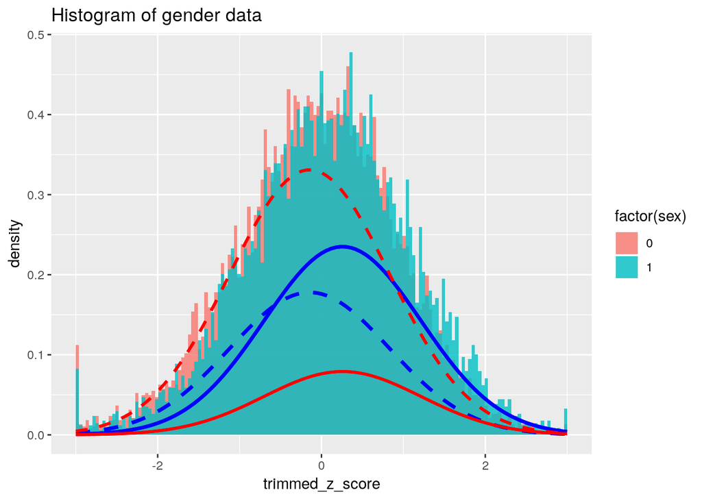

```r
list_of_pure_type_distribution_features <- list_of_names_pure_vs_mixture[pure_vs_mixture_model_llrt < rejection_region]

analyzeFullBrainFeature(results.list[names(results.list) == list_of_pure_type_distribution_features[2]],plot = T)
```

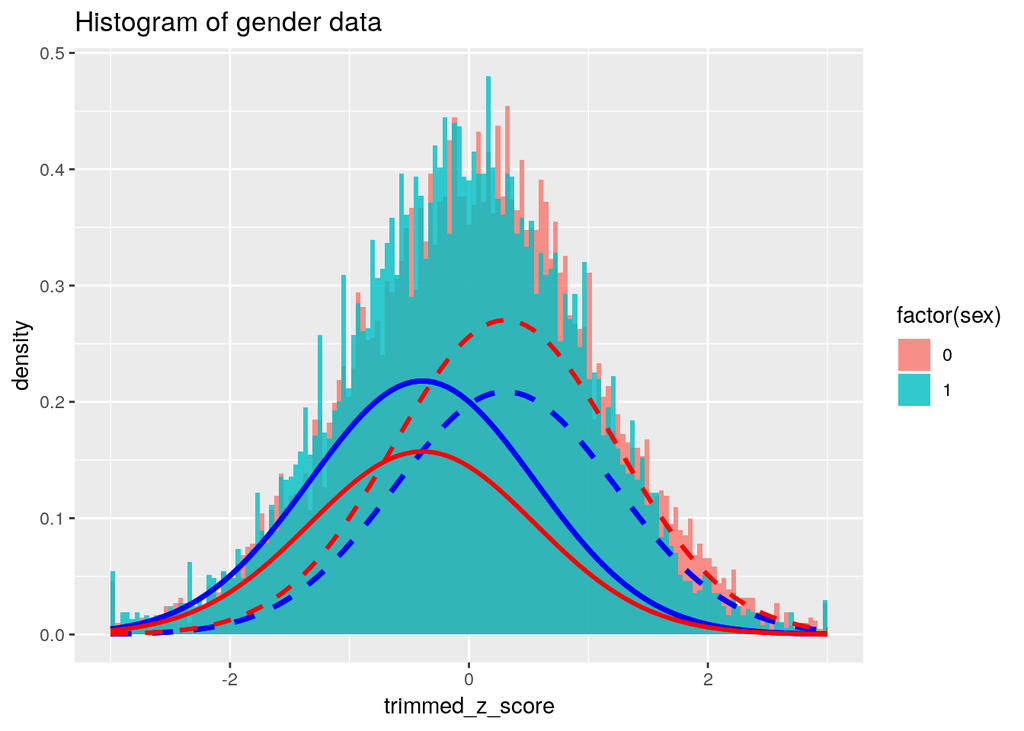

```r
analyzeFullBrainFeature(results.list[names(results.list) == list_of_pure_type_distribution_features[10]],plot = T)
```

and mixture features:

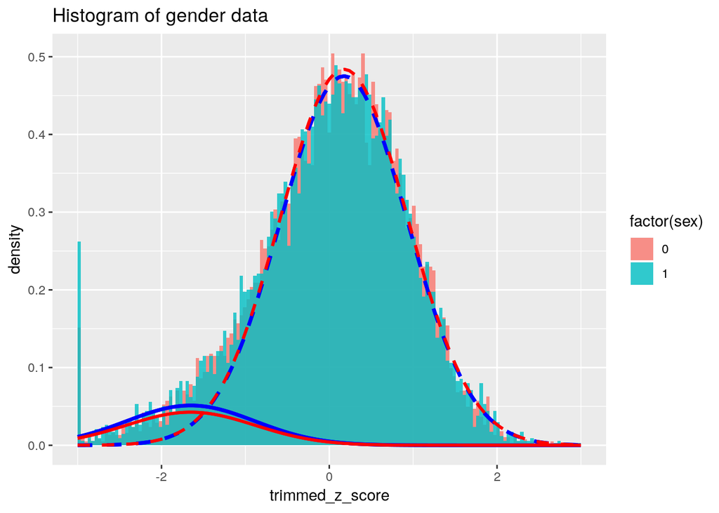

```r
list_of_mixture_type_distribution_features <- list_of_names_pure_vs_mixture[pure_vs_mixture_model_llrt > rejection_region]

analyzeFullBrainFeature(results.list[names(results.list) == list_of_mixture_type_distribution_features[2]],plot = T)
```

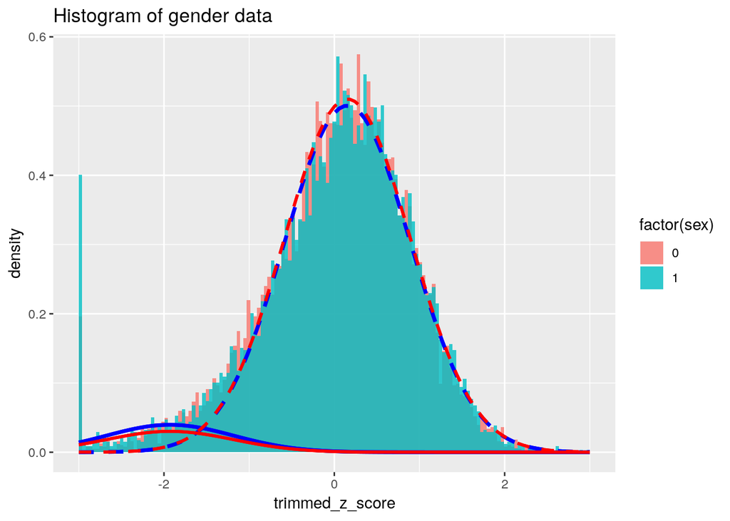

```r
analyzeFullBrainFeature(results.list[names(results.list) == list_of_mixture_type_distribution_features[10]],plot = T)
```

A special interest in our work are features that exhibit strong gender preference:

```r
mixture_features <- pure_vs_mixture_candidates[list_of_mixture_type_distribution_features]

p_level <- 0.5
q_level <- 0.5

gender_preference_features_names <- sapply(mixture_features,
                  function(x){x$hypothesis_results$pure_type_vs_mixed_gender_em_results$alternative_hypothesis$m_parameters$p > p_level &&                       x$hypothesis_results$pure_type_vs_mixed_gender_em_results$alternative_hypothesis$m_parameters$q < q_level})

gender_preference_features_names %>% table() %>% prop.table()
```

```
## .
##     FALSE      TRUE
## 0.6893204 0.3106796
```

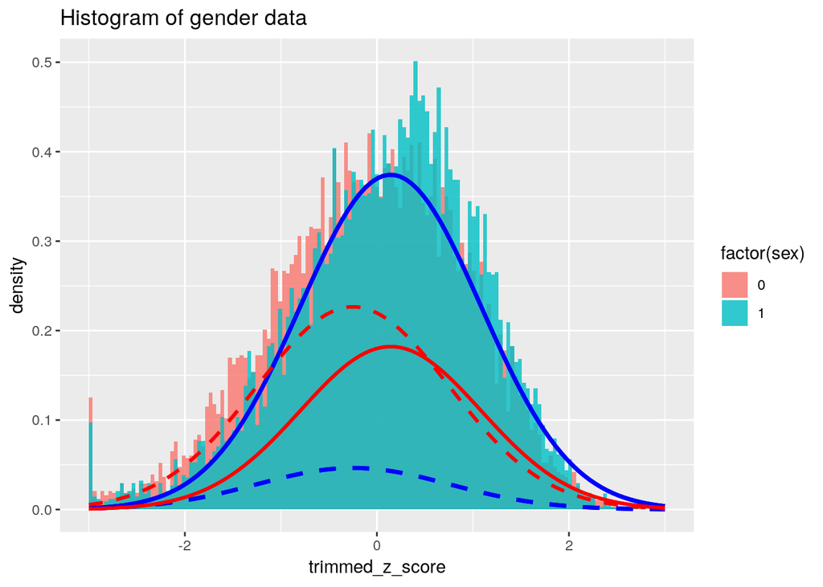

```r
gender_preference_features <- mixture_features[gender_preference_features_names]

analyzeFullBrainFeature(gender_preference_features[1],plot = T)
```

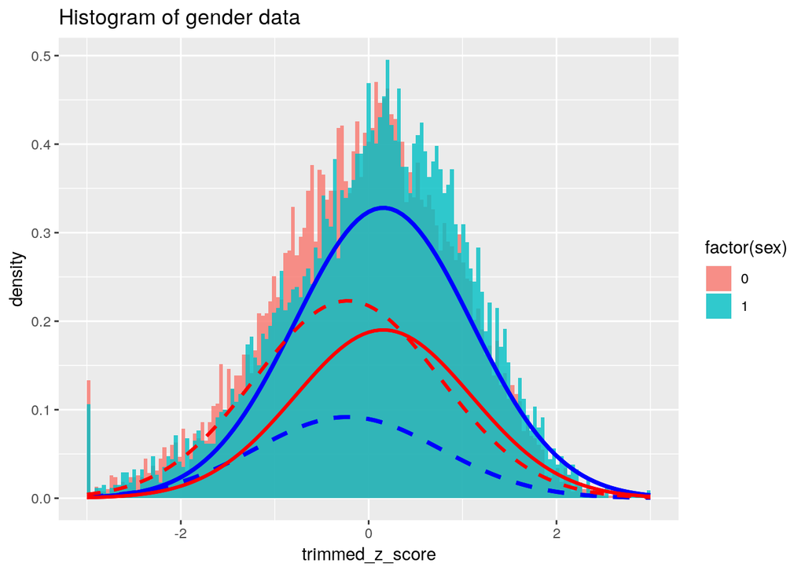

```r
analyzeFullBrainFeature(gender_preference_features[2],plot = T)
```

```r
mixture_features <- pure_vs_mixture_candidates[list_of_mixture_type_distribution_features]

p_level <- 0.65
q_level <- 0.35

gender_preference_features_names <- sapply(mixture_features,
                  function(x){x$hypothesis_results$pure_type_vs_mixed_gender_em_results$alternative_hypothesis$m_parameters$p > p_level &&                       x$hypothesis_results$pure_type_vs_mixed_gender_em_results$alternative_hypothesis$m_parameters$q < q_level})

gender_preference_features_names %>% table() %>% prop.table()
```

```
## .
##     FALSE      TRUE
## 0.8932039 0.1067961
```

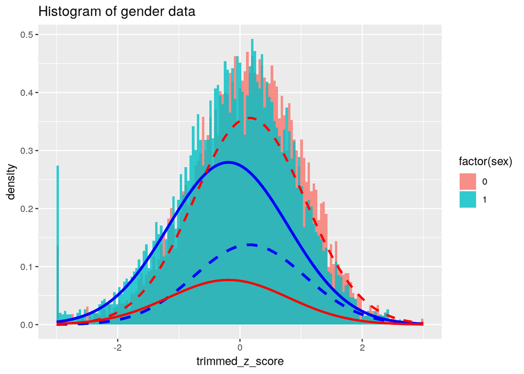

```r
gender_preference_features <- mixture_features[gender_preference_features_names]

analyzeFullBrainFeature(gender_preference_features[1],plot = T)
```

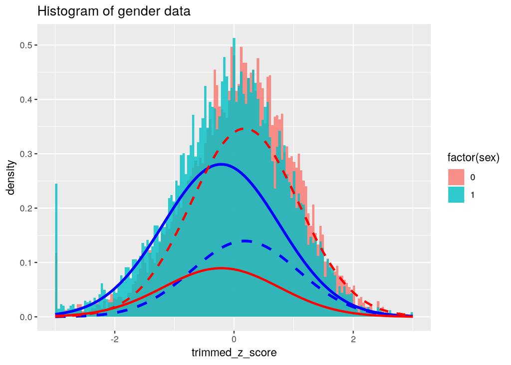

```r
analyzeFullBrainFeature(gender_preference_features[2],plot = T)
```

# Summary

The new analysis method yields very intersting results. First is seems that more features fits the single distribution model than before. Second, a visual inspection of the results shows that the new analysis method separates between pure types and mixture models with greater power.